# LAB 4

Aryan Vigyat

2023-01-06

Attaching the Libraries

```r
library(ggpubr)
```

```r
library(ggplot2)
```

1<sup>st</sup>Question  
I Loading the Dataset

```r
data = mtcars
head(data, 5)
```

```
##                    mpg cyl disp  hp drat    wt  qsec vs am gear carb
## Mazda RX4         21.0   6  160 110 3.90 2.620 16.46  0  1    4    4
## Mazda RX4 Wag     21.0   6  160 110 3.90 2.875 17.02  0  1    4    4
## Datsun 710        22.8   4  108  93 3.85 2.320 18.61  1  1    4    1
## Hornet 4 Drive    21.4   6  258 110 3.08 3.215 19.44  1  0    3    1
## Hornet Sportabout 18.7   8  360 175 3.15 3.440 17.02  0  0    3    2
```

II correlation

```r
cor(mtcars)
```

```
##             mpg        cyl       disp         hp        drat         wt
## mpg   1.0000000 -0.8521620 -0.8475514 -0.7761684  0.68117191 -0.8676594
## cyl  -0.8521620  1.0000000  0.9020329  0.8324475 -0.69993811  0.7824958
## disp -0.8475514  0.9020329  1.0000000  0.7909486 -0.71021393  0.8879799
## hp   -0.7761684  0.8324475  0.7909486  1.0000000 -0.44875912  0.6587479
## drat  0.6811719 -0.6999381 -0.7102139 -0.4487591  1.00000000 -0.7124406
## wt   -0.8676594  0.7824958  0.8879799  0.6587479 -0.71244065  1.0000000
## qsec  0.4186840 -0.5912421 -0.4336979 -0.7082234  0.09120476 -0.1747159
## vs    0.6640389 -0.8108118 -0.7104159 -0.7230967  0.44027846 -0.5549157
## am    0.5998324 -0.5226070 -0.5912270 -0.2432043  0.71271113 -0.6924953
## gear  0.4802848 -0.4926866 -0.5555692 -0.1257043  0.69961013 -0.5832870
## carb -0.5509251  0.5269883  0.3949769  0.7498125 -0.09078980  0.4276059
##             qsec         vs          am       gear        carb
## mpg   0.41868403  0.6640389  0.59983243  0.4802848 -0.55092507
## cyl  -0.59124207 -0.8108118 -0.52260705 -0.4926866  0.52698829
## disp -0.43369788 -0.7104159 -0.59122704 -0.5555692  0.39497686
## hp   -0.70822339 -0.7230967 -0.24320426 -0.1257043  0.74981247
## drat  0.09120476  0.4402785  0.71271113  0.6996101 -0.09078980
## wt   -0.17471588 -0.5549157 -0.69249526 -0.5832870  0.42760594
## qsec  1.00000000  0.7445354 -0.22986086 -0.2126822 -0.65624923
## vs    0.74453544  1.0000000  0.16834512  0.2060233 -0.56960714
## am   -0.22986086  0.1683451  1.00000000  0.7940588  0.05753435
## gear -0.21268223  0.2060233  0.79405876  1.0000000  0.27407284
## carb -0.65624923 -0.5696071  0.05753435  0.2740728  1.00000000
```

III Shapiro Test  
H0: The population is normally distributed.  
H1: The population is not normally distributed.

```r
shapiro.test(data$disp)
```

```
##
##  Shapiro-Wilk normality test
##
## data:  data$disp
## W = 0.92001, p-value = 0.02081
```

```r
shapiro.test(data$mpg)
```

```
##
##  Shapiro-Wilk normality test
##
## data:  data$mpg
## W = 0.94756, p-value = 0.1229
```

```r
shapiro.test(data$drat)
```

```
##
##  Shapiro-Wilk normality test
##
## data:  data$drat
## W = 0.94588, p-value = 0.1101
```

```r
shapiro.test(data$wt)
```

```
##
##  Shapiro-Wilk normality test
##
## data:  data$wt
## W = 0.94326, p-value = 0.09265
```

```r
shapiro.test(data$hp)
```

```
##
##  Shapiro-Wilk normality test
##
## data:  data$hp
## W = 0.93342, p-value = 0.04881
```

Inferences:-

- For Disp The P-Value is less than 0.05 which rejects the Null Hypothesis to Conclude this is not normally Distributed
- For MPG The P-Value is more than 0.05 which accepts the Null Hypothesis to Conclude this is normally Distributed
- For Drat The P-Value is more than 0.05 which accepts the Null Hypothesis to Conclude this is normally Distributed
- For wt The P-Value is more than 0.05 which accepts the Null Hypothesis to Conclude this is normally Distributed
- For hp The P-Value is less than 0.05 which rejects the Null Hypothesis to Conclude this is not normally Distributed

IV Quantile-Quantile Plot(used for checking the if the Values are normally distributed from the normal line)

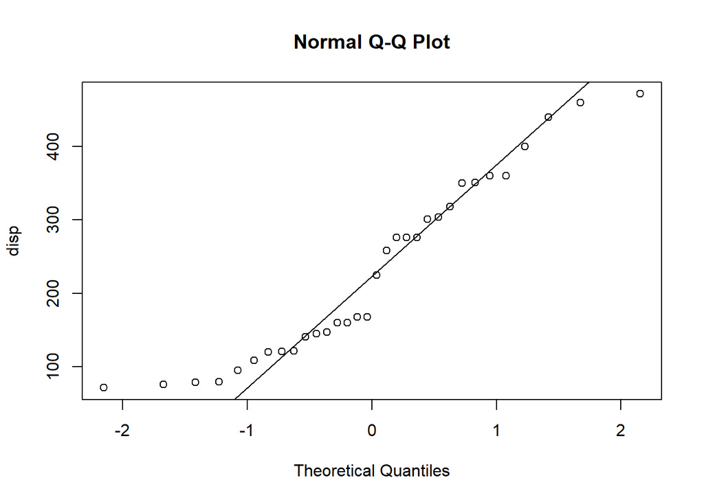

```r
qqnorm(data$disp, ylab = "disp")
qqline(data$disp)
```

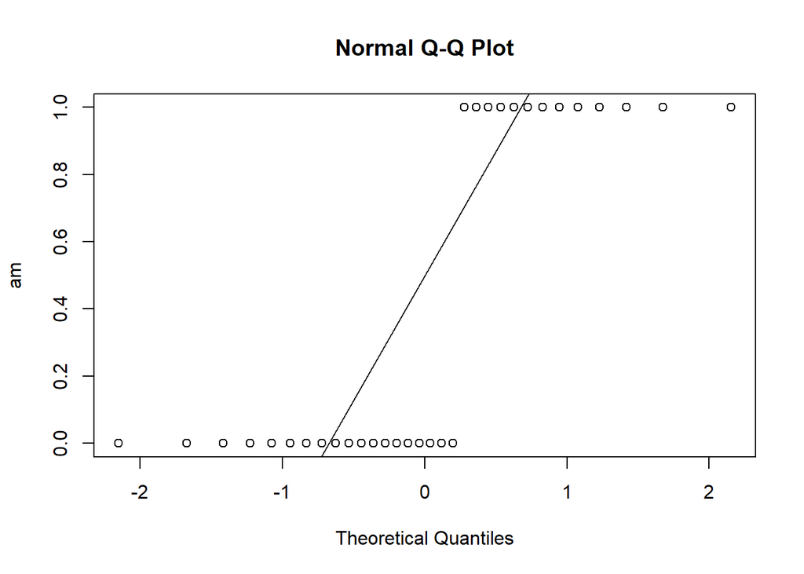

```r
qqnorm(data$am, ylab = "am")
qqline(data$am)
```

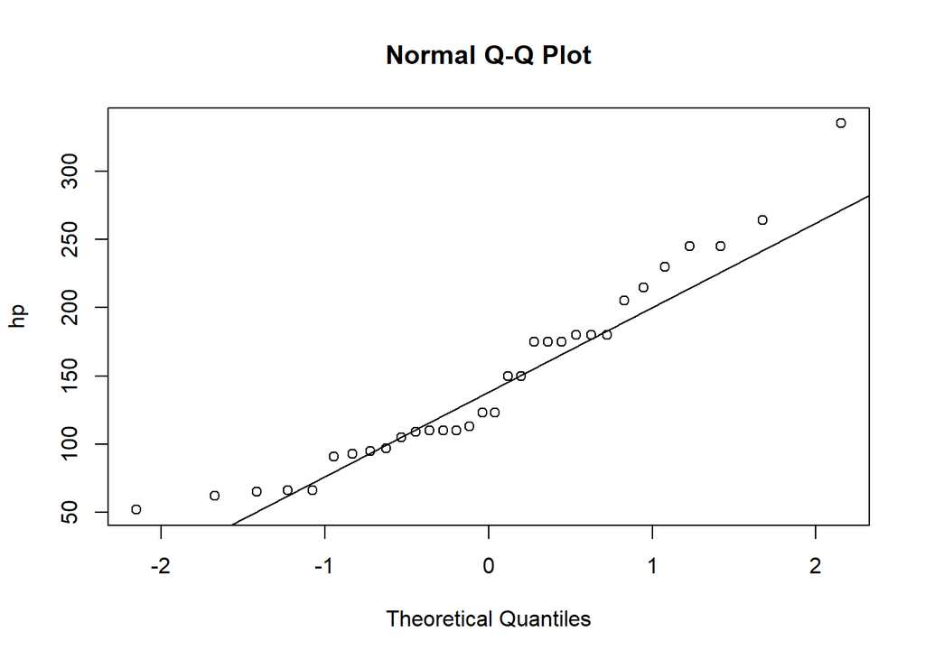

```r
qqnorm(data$hp, ylab = "hp")
qqline(data$hp)
```

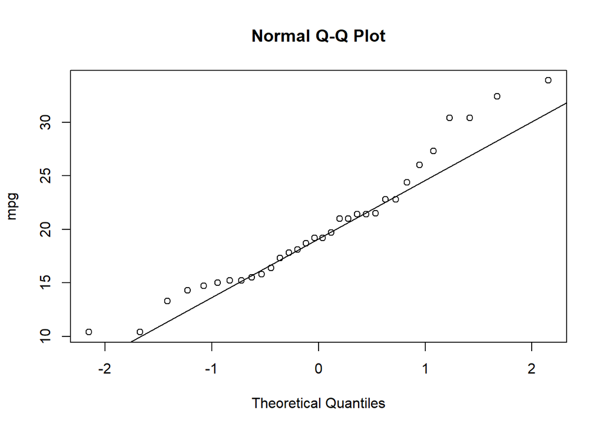

```r
qqnorm(data$mpg, ylab = "mpg")
qqline(data$mpg)
```

V Correlation Test  
H0: There is no linear Relationship between X and Y  
H1: There is a linear Relationship between X and Y

```r
cor.test(data$disp, data$am, method = "pearson")
```

```
##
##  Pearson's product-moment correlation
##
## data:  data$disp and data$am
## t = -4.0152, df = 30, p-value = 0.0003662
## alternative hypothesis: true correlation is not equal to 0
## 95 percent confidence interval:
##  -0.7792690 -0.3055178
## sample estimates:
##       cor
## -0.591227
```

```r
cor.test(data$hp, data$mpg, method = "pearson")
```

```
##
##  Pearson's product-moment correlation
##
## data:  data$hp and data$mpg
## t = -6.7424, df = 30, p-value = 1.788e-07
## alternative hypothesis: true correlation is not equal to 0
## 95 percent confidence interval:
##  -0.8852686 -0.5860994
## sample estimates:
##        cor
## -0.7761684
```

```r
cor.test(data$qsec, data$mpg, method = "pearson")
```

```
##
##  Pearson's product-moment correlation
##
## data:  data$qsec and data$mpg
## t = 2.5252, df = 30, p-value = 0.01708
## alternative hypothesis: true correlation is not equal to 0
## 95 percent confidence interval:
##  0.08195487 0.66961864
## sample estimates:
##      cor
## 0.418684
```

```r
cor.test(data$cyl, data$disp, method = "pearson")
```

```
##
##  Pearson's product-moment correlation
##
## data:  data$cyl and data$disp
## t = 11.445, df = 30, p-value = 1.803e-12
## alternative hypothesis: true correlation is not equal to 0
## 95 percent confidence interval:
##  0.8072442 0.9514607
## sample estimates:
##       cor
## 0.9020329
```

Inferences:-

- For Disp and Am the P-Value(0.0003) is Less than 0.05 , so we reject the Null Hypothesis to conclude that there is strong correlation between them and also correlation value is -0.59
- For Hp and MPG the P-Value(1.788e-07) is Less than 0.05 , so we reject the Null Hypothesis to conclude that there is strong correlation between them and also there is strong negative correlation which is -0.77
- For Qsec and MPG the P-Value(0.01) is less than 0.05, so we reject the NULL Hypothesis to conclude that there is correlation between the two variables ans also considering the cor value it is 0.41
- For Cyl and Disp the P-Value (1.803e-12) is less than 0.05 ,so we reject the NULL Hyothesis to conlude there is a strong correlation between the two variables and also the cor value is 0.90

2<sup>nd</sup> Question 1. Loading the Dataset

```r
library(readr)
library(dplyr)
library(missForest)
axisbank=read_csv("C:/Users/ayuar/Downloads/AXISBANK.csv")
summary(axisbank)
```

```
##       Date               Symbol             Series            Prev Close
##  Min.   :2000-01-03   Length:5306        Length:5306        Min.   :  22.15
##  1st Qu.:2005-04-13   Class :character   Class :character   1st Qu.: 230.95
##  Median :2010-08-17   Mode  :character   Mode  :character   Median : 519.45
##  Mean   :2010-08-18                                         Mean   : 585.76
##  3rd Qu.:2015-12-17                                         3rd Qu.: 877.31
##  Max.   :2021-04-30                                         Max.   :2023.35
##
##       Open             High             Low              Last
##  Min.   :  21.0   Min.   :  23.7   Min.   :  21.0   Min.   :  22.15
##  1st Qu.: 232.0   1st Qu.: 235.1   1st Qu.: 227.1   1st Qu.: 230.55
##  Median : 520.1   Median : 528.4   Median : 512.0   Median : 519.42
##  Mean   : 586.5   Mean   : 596.5   Mean   : 575.6   Mean   : 585.90
##  3rd Qu.: 880.1   3rd Qu.: 898.0   3rd Qu.: 852.8   3rd Qu.: 877.27
##  Max.   :2034.4   Max.   :2043.0   Max.   :2002.6   Max.   :2022.55
##
##      Close              VWAP             Volume             Turnover
##  Min.   :  22.15   Min.   :  22.17   Min.   :     2850   Min.   :8.275e+09
##  1st Qu.: 230.97   1st Qu.: 231.12   1st Qu.:   284217   1st Qu.:5.869e+12
##  Median : 519.50   Median : 519.50   Median :  1656966   Median :1.653e+14
##  Mean   : 585.89   Mean   : 586.08   Mean   :  4527938   Mean   :2.740e+14
##  3rd Qu.: 877.31   3rd Qu.: 875.81   3rd Qu.:  5515245   3rd Qu.:3.457e+14
##  Max.   :2023.35   Max.   :2020.31   Max.   :120541914   Max.   :7.180e+15
##
##      Trades       Deliverable Volume  %Deliverble
##  Min.   :  2698   Min.   :    5809   Min.   :0.0750
##  1st Qu.: 62228   1st Qu.:  257313   1st Qu.:0.3475
##  Median : 93187   Median :  768768   Median :0.4598
##  Mean   :120602   Mean   : 1990907   Mean   :0.4670
##  3rd Qu.:144973   3rd Qu.: 2652520   3rd Qu.:0.5739
##  Max.   :990737   Max.   :94901165   Max.   :0.9830
##  NA's   :2850     NA's   :509        NA's   :509
```

```r
head(axisbank,5)
```

```
## # A tibble: 5 × 15
##   Date       Symbol  Series Prev Cl…¹  Open  High   Low  Last Close  VWAP Volume
##   <date>     <chr>   <chr>      <dbl> <dbl> <dbl> <dbl> <dbl> <dbl> <dbl>  <dbl>
## 1 2000-01-03 UTIBANK EQ          24.7  26.7  26.7  26.7  26.7  26.7  26.7 112100
## 2 2000-01-04 UTIBANK EQ          26.7  27    28.7  26.5  27    26.8  27.2 234500
## 3 2000-01-05 UTIBANK EQ          26.8  26    27.8  25.5  26.4  26.3  26.2 170100
## 4 2000-01-06 UTIBANK EQ          26.3  25.8  27    25.8  25.9  26.0  26.3 102100
## 5 2000-01-07 UTIBANK EQ          26.0  25    26    24.2  25    24.8  25.0  62600
## # … with 4 more variables: Turnover <dbl>, Trades <dbl>,
## #   `Deliverable Volume` <dbl>, `%Deliverble` <dbl>, and abbreviated variable
## #   name ¹`Prev Close`
```

2. Selecting the Columns for Correlation

```r
axisbank<-axisbank %>%
  select('Open','High','Low','Volume','Close')
```

3. Checking For NA Values and Inputation

```r
sum(is.na(axisbank))
```

```
## [1] 0
```

```r
bankdf=prodNA(axisbank,0.3)
bankdf=bankdf[-(1:400),]
bankdf %>%
  summarize(avg=mean(Open,na.rm = TRUE),med=median(Open,na.rm = TRUE))
```

```
## # A tibble: 1 × 2
##     avg   med
##   <dbl> <dbl>
## 1  630.  546.
```

```r
bankdf <- bankdf %>%
  mutate(Open=replace(Open,is.na(Open),median(Open,na.rm = TRUE)))
bankdf %>%
  summarize(avg=mean(High,na.rm = TRUE),med=median(High,na.rm = TRUE))
```

```
## # A tibble: 1 × 2
##     avg   med
##   <dbl> <dbl>
## 1  637.  552.
```

```r
bankdf <- bankdf %>%
  mutate(High=replace(High,is.na(High),median(High,na.rm = TRUE)))
bankdf %>%
  summarize(avg=mean(Low,na.rm = TRUE),med=median(Low,na.rm = TRUE))
```

```
## # A tibble: 1 × 2
##     avg   med
##   <dbl> <dbl>
## 1  613.  533.
```

```r
bankdf <- bankdf %>%
  mutate(Low=replace(Low,is.na(Low),median(Low,na.rm = TRUE)))
bankdf %>%
  summarize(avg=mean(Volume,na.rm = TRUE),med=median(Volume,na.rm = TRUE))
```

```
## # A tibble: 1 × 2
##        avg     med
##      <dbl>   <dbl>
## 1 5012461. 1994820
```

```r
bankdf <- bankdf %>%
  mutate(Volume=replace(Volume,is.na(Volume),median(Volume,na.rm = TRUE)))
bankdf %>%
  summarize(avg=mean(Close,na.rm = TRUE),med=median(Close,na.rm = TRUE))
```

```
## # A tibble: 1 × 2
##     avg   med
##   <dbl> <dbl>
## 1  634.   546
```

```r
bankdf <- bankdf %>%
  mutate(Close=replace(Close,is.na(Close),median(Close,na.rm = TRUE)))
```

4. Correlation Test  
   H0: There is no linear Relationship between X and Y  
   H1: There is a linear Relationship between X and Y

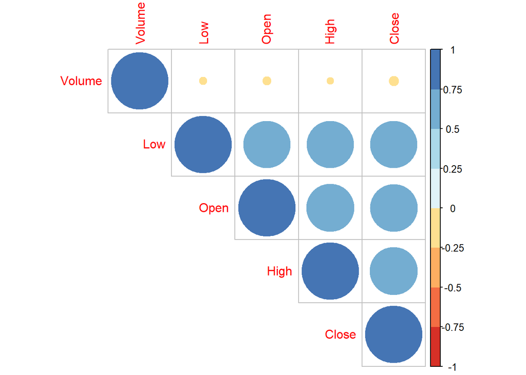

```r
library(RColorBrewer) #
library(corrplot) #Drawing Correlation Plot
M<-cor(bankdf)
corrplot(M, type="upper", order="hclust",
         col=brewer.pal(n=8, name="RdYlBu"))
```

```r
cor.test(bankdf$High,bankdf$Low,method = "pearson")
```

```
##
##  Pearson's product-moment correlation
##
## data:  bankdf$High and bankdf$Low
## t = 63.923, df = 4904, p-value < 2.2e-16
## alternative hypothesis: true correlation is not equal to 0
## 95 percent confidence interval:
##  0.6586199 0.6891600
## sample estimates:
##       cor
## 0.6741781
```

```r
print("Considering the P less than 0.05 Value as well as the Correlation Value we reject the Null Hypothesis and Say there is a high correlation between the two variables")
```

```
## [1] "Considering the P less than 0.05 Value as well as the Correlation Value we reject the Null Hypothesis and Say there is a high correlation between the two variables"
```

```r
cor.test(bankdf$Open,bankdf$Close,method = "pearson")
```

```
##
##  Pearson's product-moment correlation
##
## data:  bankdf$Open and bankdf$Close
## t = 65.328, df = 4904, p-value < 2.2e-16
## alternative hypothesis: true correlation is not equal to 0
## 95 percent confidence interval:
##  0.6668885 0.6968241
## sample estimates:
##       cor
## 0.6821421
```

```r
print("Considering the P less than 0.05 Value as well as the Correlation Value we reject the Null Hypothesis and Say there is a high correlation between the two variables")
```

```
## [1] "Considering the P less than 0.05 Value as well as the Correlation Value we reject the Null Hypothesis and Say there is a high correlation between the two variables"
```

```r
cor.test(bankdf$Volume,bankdf$High,method = "pearson")
```

```
##
##  Pearson's product-moment correlation
##
## data:  bankdf$Volume and bankdf$High
## t = -1.0905, df = 4904, p-value = 0.2755
## alternative hypothesis: true correlation is not equal to 0
## 95 percent confidence interval:
##  -0.04353538  0.01241829
## sample estimates:
##         cor
## -0.01557074
```

```r
print("Considering the P Greater than 0.05 Value as well as the Correlation Value we accept the Null Hypothesis and Say there is a negligible correlation between the two variables")
```

```
## [1] "Considering the P Greater than 0.05 Value as well as the Correlation Value we accept the Null Hypothesis and Say there is a negligible correlation between the two variables"
```

```r
cor.test(bankdf$Low,bankdf$Volume,method = "pearson")
```

```
##
##  Pearson's product-moment correlation
##
## data:  bankdf$Low and bankdf$Volume
## t = -1.3539, df = 4904, p-value = 0.1758
## alternative hypothesis: true correlation is not equal to 0
## 95 percent confidence interval:
##  -0.047287369  0.008658957
## sample estimates:
##         cor
## -0.01932934
```

```r
print("Considering the P Greater than 0.05 Value as well as the Correlation Value we accept the Null Hypothesis and Say there is a negligible correlation between the two variables")
```

```
## [1] "Considering the P Greater than 0.05 Value as well as the Correlation Value we accept the Null Hypothesis and Say there is a negligible correlation between the two variables"
```

4. Drawing the Q-Q Plots

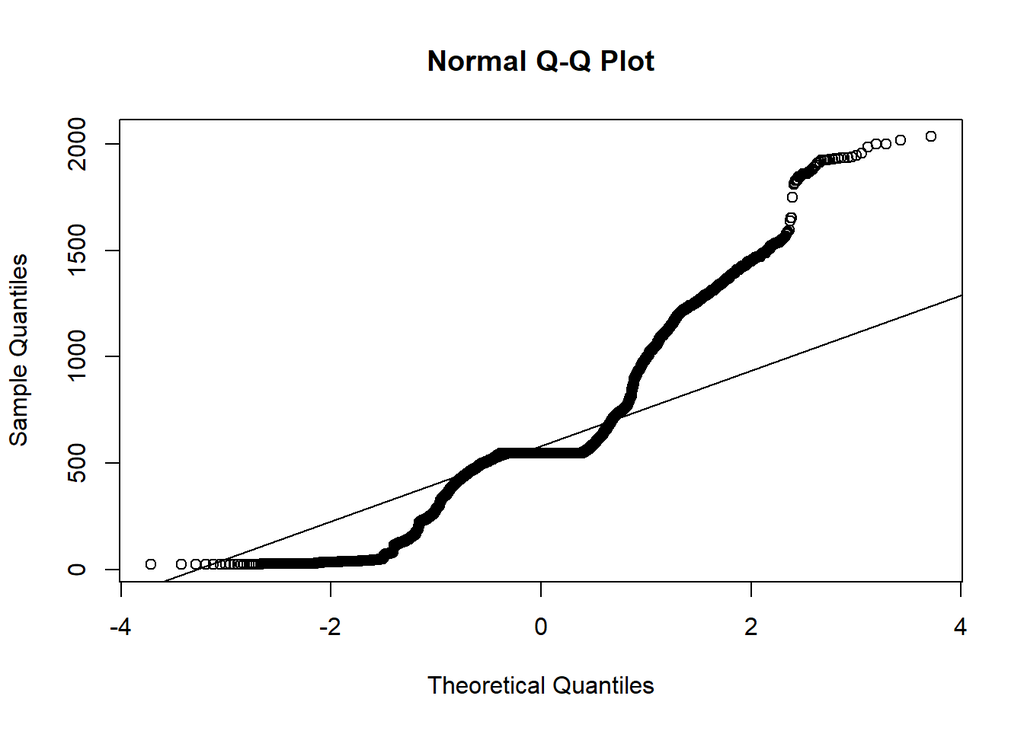

```r
#Used to check if the values are normally distributed with the normal line
qqnorm(bankdf$Open)
qqline(bankdf$Open)
```

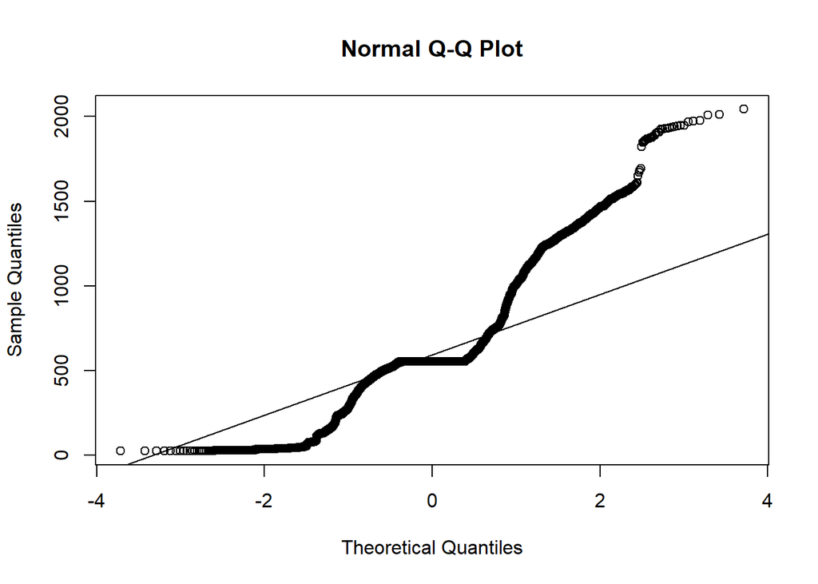

```r
qqnorm(bankdf$High)
qqline(bankdf$High)
```

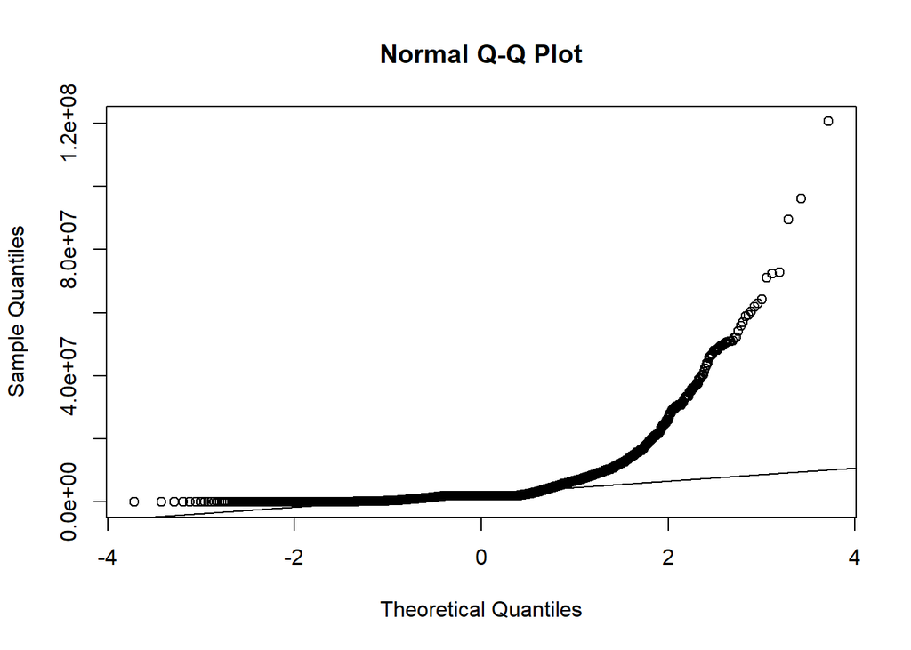

```r
qqnorm(bankdf$Volume)
qqline(bankdf$Volume)
```

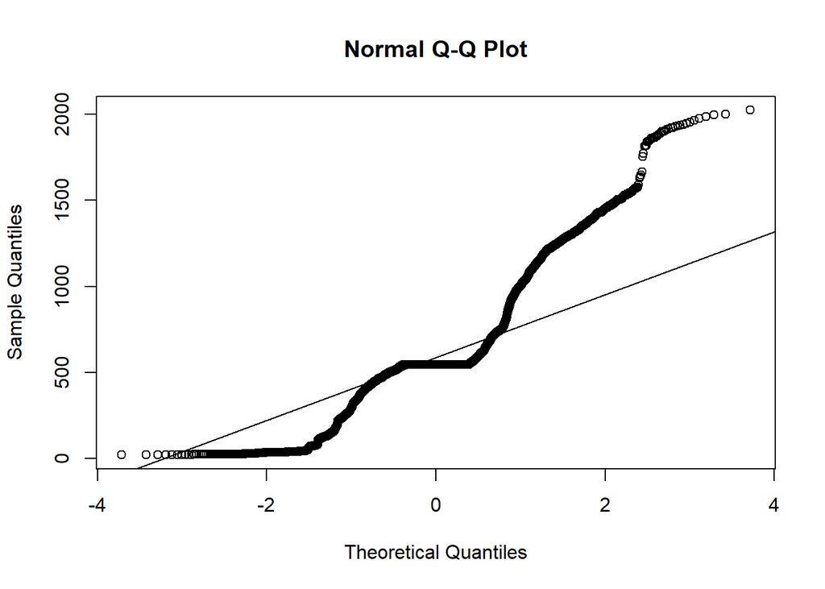

```r
qqnorm(bankdf$Close)
qqline(bankdf$Close)
```

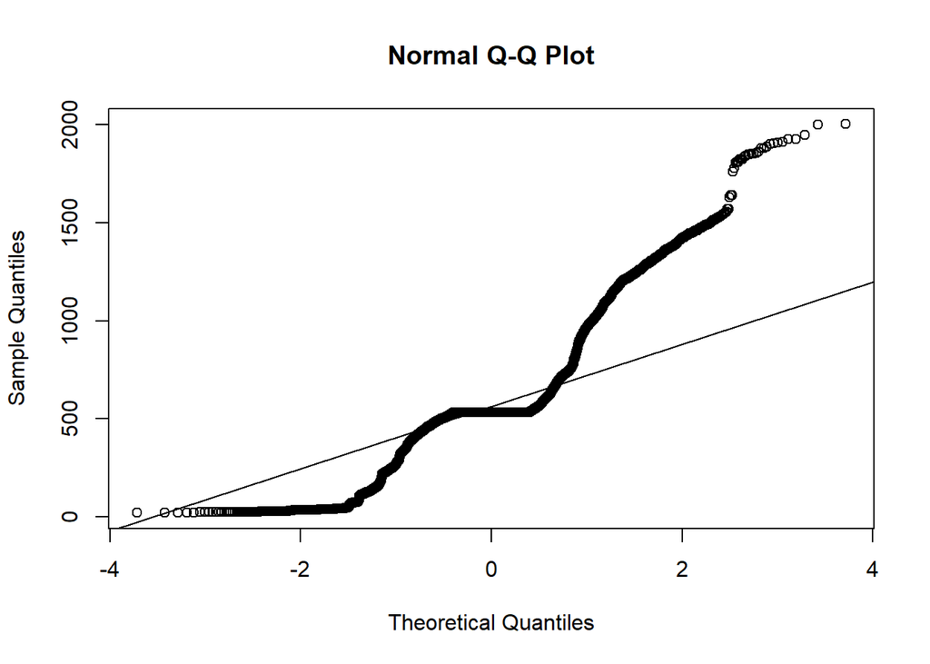

```r
qqnorm(bankdf$Low)
qqline(bankdf$Low)
```

5. Shapiro Test  
   H0: The population is normally distributed.  
   H1: The population is not normally distributed.

```r
shapiro.test(bankdf$Open)
```

```
##
##  Shapiro-Wilk normality test
##
## data:  bankdf$Open
## W = 0.89535, p-value < 2.2e-16
```

```r
shapiro.test(bankdf$Close)
```

```
##
##  Shapiro-Wilk normality test
##
## data:  bankdf$Close
## W = 0.89799, p-value < 2.2e-16
```

```r
shapiro.test(bankdf$High)
```

```
##
##  Shapiro-Wilk normality test
##
## data:  bankdf$High
## W = 0.89835, p-value < 2.2e-16
```

```r
shapiro.test(bankdf$Low)
```

```
##
##  Shapiro-Wilk normality test
##
## data:  bankdf$Low
## W = 0.89335, p-value < 2.2e-16
```

```r
shapiro.test(bankdf$Volume)
```

```
##
##  Shapiro-Wilk normality test
##
## data:  bankdf$Volume
## W = 0.48594, p-value < 2.2e-16
```

Inferences

- For All the Variables ,As the P value is less than 0.05 we reject the Null Hypothesis to concude that variable is not normally distributed which is weighed upon by the Quantile-Quantile Plot which shows the deviations of the values dont seem to be normally distributed

Time and Date Verification

```r
Sys.info()
```

```
##           sysname           release           version          nodename
##         "Windows"          "10 x64"     "build 22000" "LAPTOP-8VGUQE0S"
##           machine             login              user    effective_user
##          "x86-64"           "ayuar"           "ayuar"           "ayuar"
```

```r
Sys.time()
```

```
## [1] "2023-01-06 23:01:45 IST"
```

```r
Sys.Date()
```

```
## [1] "2023-01-06"
```